# Figure 6: Compartment-specific PKA inhibition

# Fig 6C

MIC60 phosphorylation relative to total MIC60 following homeostatic plasticity, with compartment-specific PKA inhibition.

**Source data**  
`Fig 6C.csv`

**Columns**

- `Date` — Experiment date
- `Condition` — Control, Matrix-PKI, or IMS-PKI construct
- `Treatment` — Control or TTX
- `phosphoMic60_ratio` — Phosphorylated MIC60 / total MIC60

## Data

Each date contributes one ratio per construct and treatment combination.

```r
condition_order <- c("Control", "Matrix-PKI", "IMS-PKI")
treatment_order <- c("Control", "TTX")
group_order <- c("Control Control", "Control TTX", "Matrix-PKI Control", "Matrix-PKI TTX", "IMS-PKI Control", "IMS-PKI TTX")
spacing_map <- c("Control Control" = 1, "Control TTX" = 2.2, "Matrix-PKI Control" = 4, "Matrix-PKI TTX" = 5.2, "IMS-PKI Control" = 7, "IMS-PKI TTX" = 8.2)

Intensity_df <- read_csv("./Fig 6C.csv", show_col_types = FALSE)
if (!"ratio" %in% names(Intensity_df) && "phosphoMic60_ratio" %in% names(Intensity_df)) Intensity_df <- rename(Intensity_df, ratio = phosphoMic60_ratio)
missing_columns <- setdiff(c("Date", "Condition", "Treatment", "ratio"), names(Intensity_df))
if (length(missing_columns)) stop("Missing columns: ", paste(missing_columns, collapse = ", "))

Intensity_df <- Intensity_df %>%
  mutate(
    Date = trimws(as.character(Date)),
    Condition = case_when(Condition %in% c("Mt-PKI", "Matrix PKI") ~ "Matrix-PKI", Condition == "IMS PKI" ~ "IMS-PKI", TRUE ~ trimws(as.character(Condition))),
    Treatment = case_when(Treatment %in% c("-TTX", "(-TTX)") ~ "Control", Treatment %in% c("+TTX", "(+TTX)") ~ "TTX", TRUE ~ trimws(as.character(Treatment))),
    ratio = as.numeric(ratio),
    Condition = factor(Condition, levels = condition_order),
    Treatment = factor(Treatment, levels = treatment_order),
    Group = factor(paste(Condition, Treatment), levels = group_order),
    x_pos = unname(spacing_map[as.character(Group)]),
    Date = factor(Date)
  ) %>%
  filter(!is.na(Date), Date != "", !is.na(Group), is.finite(ratio))

design_check <- Intensity_df %>% group_by(Date) %>% summarise(n = n(), n_Groups = n_distinct(Group), .groups = "drop")
if (nrow(design_check) < 2 || any(design_check$n != 6 | design_check$n_Groups != 6)) stop("At least two dates are required, each with one value for all six groups.")

Intensity_df %>% mutate(across(where(is.numeric), ~ round(.x, 3)))
```

| Date | Condition | Treatment | ratio | Group | x_pos |
| --- | --- | --- | --- | --- | --- |
| 2026-04-16 | Control | Control | 0.043 | Control Control | 1.0 |
| 2026-04-16 | Control | TTX | 0.153 | Control TTX | 2.2 |
| 2026-04-16 | Matrix-PKI | Control | 0.169 | Matrix-PKI Control | 4.0 |
| 2026-04-16 | Matrix-PKI | TTX | 0.148 | Matrix-PKI TTX | 5.2 |
| 2026-04-16 | IMS-PKI | Control | 0.113 | IMS-PKI Control | 7.0 |
| 2026-04-16 | IMS-PKI | TTX | 0.113 | IMS-PKI TTX | 8.2 |
| 2026-07-24 | Control | Control | 0.241 | Control Control | 1.0 |
| 2026-07-24 | Control | TTX | 0.430 | Control TTX | 2.2 |
| 2026-07-24 | Matrix-PKI | Control | 0.288 | Matrix-PKI Control | 4.0 |
| 2026-07-24 | Matrix-PKI | TTX | 0.250 | Matrix-PKI TTX | 5.2 |

[output cut: 20 more lines]

## Summary

```r
summary_table <- Intensity_df %>%
  group_by(Group) %>%
  summarise(n_Experiment_Dates = n_distinct(Date), `Mean (SE)` = sprintf("%.3f (%.3f)", mean(ratio), sd(ratio) / sqrt(n())), .groups = "drop")

summary_table
```

| Group | n_Experiment_Dates | Mean (SE) |
| --- | --- | --- |
| Control Control | 5 | 0.197 (0.049) |
| Control TTX | 5 | 0.310 (0.056) |
| Matrix-PKI Control | 5 | 0.225 (0.047) |
| Matrix-PKI TTX | 5 | 0.223 (0.023) |
| IMS-PKI Control | 5 | 0.167 (0.061) |
| IMS-PKI TTX | 5 | 0.338 (0.079) |

## Statistics

Matched two-way ANOVA for construct and treatment, matched by experiment date. Treatment contrasts within construct use Tukey adjustment.

```r
stats_df <- Intensity_df %>%
  mutate(
    Condition_stat = factor(c("Control" = "Control", "Matrix-PKI" = "MatrixPKI", "IMS-PKI" = "IMSPKI")[as.character(Condition)],
                            levels = c("Control", "MatrixPKI", "IMSPKI")),
    Treatment_stat = factor(Treatment, levels = c("Control", "TTX"))
  )

options(contrasts = c("contr.sum", "contr.poly"))
fit_aov <- aov(ratio ~ Condition_stat * Treatment_stat +
                Error(Date / (Condition_stat * Treatment_stat)), data = stats_df)

summary(fit_aov)
```

```
##
## Error: Date
##           Df Sum Sq Mean Sq F value Pr(>F)
## Residuals  4 0.2462 0.06154
##
## Error: Date:Condition_stat
##                Df  Sum Sq  Mean Sq F value Pr(>F)
## Condition_stat  2 0.00548 0.002740   0.463  0.645
## Residuals       8 0.04738 0.005923
##
## Error: Date:Treatment_stat
##                Df  Sum Sq Mean Sq F value Pr(>F)
## Treatment_stat  1 0.06604 0.06604   10.45 0.0319 *
## Residuals       4 0.02528 0.00632
## ---
## Signif. codes:  0 '***' 0.001 '**' 0.01 '*' 0.05 '.' 0.1 ' ' 1
##
## Error: Date:Condition_stat:Treatment_stat
##                               Df  Sum Sq  Mean Sq F value Pr(>F)
## Condition_stat:Treatment_stat  2 0.03869 0.019344   3.263  0.092 .
## Residuals                      8 0.04743 0.005928
## ---
## Signif. codes:  0 '***' 0.001 '**' 0.01 '*' 0.05 '.' 0.1 ' ' 1
```

```r
format_p <- function(p) ifelse(p < 0.0001, "<0.0001", sprintf("%.4f", p))
p_to_stars <- function(p) case_when(p < 0.001 ~ "***", p < 0.01 ~ "**", p < 0.05 ~ "*", TRUE ~ "ns")

treatment_means <- emmeans::emmeans(fit_aov, ~ Treatment_stat | Condition_stat)
ttx_effects <- emmeans::contrast(treatment_means, "revpairwise", adjust = "tukey") %>%
  as.data.frame() %>%
  mutate(Condition = c("Control" = "Control", "MatrixPKI" = "Matrix-PKI", "IMSPKI" = "IMS-PKI")[as.character(Condition_stat)])

means_table <- as.data.frame(treatment_means) %>%
  mutate(
    Condition = c("Control" = "Control", "MatrixPKI" = "Matrix-PKI", "IMSPKI" = "IMS-PKI")[as.character(Condition_stat)],
    `Mean (SE)` = sprintf("%.3f (%.3f)", emmean, SE)
  ) %>%
  select(Condition, Treatment_stat, `Mean (SE)`) %>%
  tidyr::pivot_wider(names_from = Treatment_stat, values_from = `Mean (SE)`, names_glue = "{Treatment_stat} mean (SE)")

stats_table <- ttx_effects %>%
  transmute(Condition, Comparison = "Control vs TTX", `p value` = format_p(p.value)) %>%
  left_join(means_table, by = "Condition") %>%
  select(Condition, Comparison, `Control mean (SE)`, `TTX mean (SE)`, `p value`)

stats_table
```

| Condition | Comparison | Control mean (SE) | TTX mean (SE) | p value |
| --- | --- | --- | --- | --- |
| Control | Control vs TTX | 0.197 (0.055) | 0.310 (0.055) | 0.0407 |
| Matrix-PKI | Control vs TTX | 0.225 (0.055) | 0.223 (0.055) | 0.9667 |
| IMS-PKI | Control vs TTX | 0.167 (0.055) | 0.338 (0.055) | 0.0047 |

## Plot

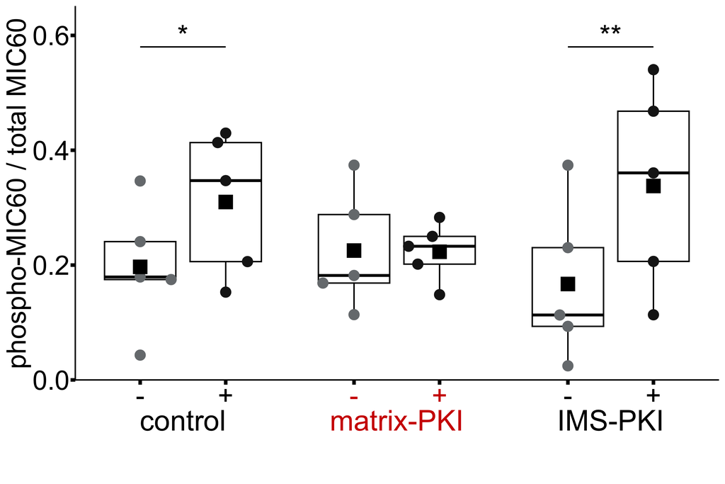

```r
set.seed(20261109)
label_red <- "#D00000"
group_colors <- c("Control Control" = "#777B7E", "Control TTX" = "#1A1A1A", "Matrix-PKI Control" = "#777B7E", "Matrix-PKI TTX" = "#1A1A1A", "IMS-PKI Control" = "#777B7E", "IMS-PKI TTX" = "#1A1A1A")

plot_stats <- as.data.frame(ttx_effects) %>%
  mutate(
    group1_x = unname(spacing_map[paste(Condition, "Control")]),
    group2_x = unname(spacing_map[paste(Condition, "TTX")]),
    y_position = if_else(Condition %in% c("Control", "IMS-PKI"), 0.58, 0.54),
    stars = p_to_stars(p.value)
  ) %>% filter(stars != "ns")

group_labels <- tibble(x = c(1.6, 4.6, 7.6), y = -0.07,
                       label = c("control", "matrix-PKI", "IMS-PKI"))

tick_labels <- c(
  "<span>-</span>", "<span>+</span>",
  paste0("<span style='color:", label_red, "'>-</span>"),
  paste0("<span style='color:", label_red, "'>+</span>"),
  "<span>-</span>", "<span>+</span>"
)

fig6c_plot <- ggplot(Intensity_df, aes(x_pos, ratio, color = Group)) +
  geom_boxplot(aes(group = x_pos), fill = NA, width = 1, outlier.shape = NA, linewidth = 2, color = "black") +
  ggbeeswarm::geom_beeswarm(cex = 9, priority = "random", size = 15, corral = "random") +
  stat_summary(aes(group = x_pos), fun = mean, geom = "point", shape = 15, size = 20, color = "black") +
  geom_segment(data = plot_stats, aes(x = group1_x, xend = group2_x, y = y_position, yend = y_position),
               inherit.aes = FALSE, linewidth = 2, color = "black") +
  geom_text(data = plot_stats, aes(x = (group1_x + group2_x) / 2, y = y_position + 0.02, label = stars),
            inherit.aes = FALSE, size = 30, color = "black") +
  geom_text(data = filter(group_labels, label != "matrix-PKI"), aes(x, y, label = label),
            inherit.aes = FALSE, size = 30, color = "black") +
  geom_text(data = filter(group_labels, label == "matrix-PKI"), aes(x, y, label = label),
            inherit.aes = FALSE, size = 30, color = label_red) +
  scale_x_continuous(breaks = unname(spacing_map), labels = tick_labels) +
  scale_color_manual(values = group_colors, breaks = group_order) +
  scale_y_continuous(breaks = c(0, 0.2, 0.4, 0.6), expand = c(0, 0)) +
  coord_cartesian(ylim = c(0, 0.65), clip = "off") +
  labs(x = NULL, y = "phospho-MIC60 / total MIC60") +
  theme_classic() +
  theme(axis.title = element_text(size = 80, color = "black"),
        axis.text = element_text(size = 80, color = "black"),
        axis.text.x = ggtext::element_markdown(size = 80, color = "black"),
        axis.ticks = element_line(linewidth = 5, color = "black"),
        axis.ticks.length = grid::unit(0.5, "cm"),
        axis.line = element_line(linewidth = 2, color = "black"),
        plot.margin = margin(20, 20, 220, 20),
        legend.position = "none")

fig6c_plot
```

# Fig 6D

Mitochondrial area by region and homeostatic-plasticity treatment in Matrix-PKI-expressing neurons.

**Source data**  
`Fig 6D juxta.csv`, `Fig 6D nonjuxta.csv`

**Columns**

- `Date` — Experiment date
- `Condition` — Control or TTX
- `Dish` — Culture dish ID
- `Cell` — Cell ID
- `mito_area_um2` — Mean mitochondrial area per cell (µm²)

## Data

The input file identifies the region type. All cells express Matrix-PKI.

```r
spacing_map <- c("Juxta Control" = 1, "Juxta TTX" = 2.2, "Non Juxta Control" = 3.8, "Non Juxta TTX" = 5)

juxta_df <- read_csv("./Fig 6D juxta.csv", show_col_types = FALSE) %>%
  select(Date, Condition, Dish, Cell, mito_area_um2) %>% mutate(Region = "Juxta")
nonjuxta_df <- read_csv("./Fig 6D nonjuxta.csv", show_col_types = FALSE) %>%
  select(Date, Condition, Dish, Cell, mito_area_um2) %>% mutate(Region = "Non Juxta")

mito_df <- bind_rows(juxta_df, nonjuxta_df) %>%
  mutate(Condition = trimws(as.character(Condition))) %>%
  filter(grepl("Matrix-PKI", Condition, ignore.case = TRUE)) %>%
  mutate(
    Condition = case_when(
      grepl("^Control", Condition, ignore.case = TRUE) ~ "Control",
      grepl("^TTX", Condition, ignore.case = TRUE) ~ "TTX"
    ),
    Date = factor(trimws(as.character(Date))),
    Condition = factor(Condition, levels = c("Control", "TTX")),
    Region = factor(Region, levels = c("Juxta", "Non Juxta")),
    mito_area_um2 = as.numeric(mito_area_um2),
    Group = factor(paste(Region, Condition), levels = names(spacing_map)),
    x_pos = unname(spacing_map[as.character(Group)]),
    Group_Date = paste(Group, Date, sep = "_")
  ) %>%
  filter(!is.na(Date), !is.na(Condition), !is.na(Region), is.finite(mito_area_um2))

if (!nrow(mito_df) || n_distinct(mito_df$Group) < 4 || n_distinct(mito_df$Date) < 2)
  stop("All four Condition x Region groups and at least two dates are required.")

mito_df %>%
  select(Date, Condition, Dish, Cell, Region, mito_area_um2) %>%
  mutate(across(where(is.numeric), ~ round(.x, 3)))
```

| Date | Condition | Dish | Cell | Region | mito_area_um2 |
| --- | --- | --- | --- | --- | --- |
| 2026-07-08 | Control | 1 | 2 | Juxta | 1.209 |
| 2026-07-08 | Control | 1 | 3 | Juxta | 0.912 |
| 2026-07-08 | Control | 1 | 4 | Juxta | 0.996 |
| 2026-07-08 | Control | 1 | 8 | Juxta | 1.056 |
| 2026-07-08 | Control | 2 | 1 | Juxta | 0.784 |
| 2026-07-08 | Control | 2 | 2 | Juxta | 0.809 |
| 2026-07-08 | Control | 2 | 3 | Juxta | 0.508 |
| 2026-07-08 | Control | 2 | 5 | Juxta | 0.873 |
| 2026-07-08 | Control | 2 | 6 | Juxta | 0.917 |
| 2026-07-08 | TTX | 1 | 1 | Juxta | 1.254 |

[output cut: 98 more lines]

## Summary

```r
summary_table <- mito_df %>%
  group_by(Group) %>%
  summarise(
    n_Cells = n_distinct(Date, Dish, Cell),
    n_Experiment_Dates = n_distinct(Date),
    `Mean (SE)` = sprintf("%.3f (%.3f)", mean(mito_area_um2),
                          sd(mito_area_um2) / sqrt(n())),
    .groups = "drop"
  )

summary_table
```

| Group | n_Cells | n_Experiment_Dates | Mean (SE) |
| --- | --- | --- | --- |
| Juxta Control | 24 | 3 | 0.944 (0.040) |
| Juxta TTX | 30 | 3 | 0.999 (0.034) |
| Non Juxta Control | 24 | 3 | 0.488 (0.025) |
| Non Juxta TTX | 30 | 3 | 0.535 (0.024) |

## Statistics

Three-way ANOVA with condition, region, experiment date, and their interactions (Type I sums of squares). Pairwise comparisons use Tukey adjustment.

```r
format_p <- function(p) ifelse(is.na(p), NA_character_,
                               ifelse(p < 0.0001, "<0.0001", sprintf("%.4f", p)))
p_to_stars <- function(p) case_when(
  is.na(p) ~ NA_character_, p < 0.001 ~ "***",
  p < 0.01 ~ "**", p < 0.05 ~ "*", TRUE ~ "ns"
)

fit_aov <- aov(mito_area_um2 ~ Condition * Region * Date, data = mito_df)
aov_tab <- anova(fit_aov)

anova_table <- as.data.frame(aov_tab) %>%
  tibble::rownames_to_column("Effect") %>%
  filter(trimws(Effect) != "Residuals") %>%
  transmute(
    Effect = dplyr::recode(
      trimws(Effect),
      Condition = "Condition", Region = "Region", Date = "Date",
      `Condition:Region` = "Condition x Region",
      `Condition:Date` = "Condition x Date",
      `Region:Date` = "Region x Date",
      `Condition:Region:Date` = "Condition x Region x Date"
    ),
    df = Df, F = round(`F value`, 3), `p value` = format_p(`Pr(>F)`)
  )

anova_table
```

| Effect | df | F | p value |
| --- | --- | --- | --- |
| Condition | 1 | 2.894 | 0.0921 |
| Region | 1 | 236.459 | <0.0001 |
| Date | 2 | 1.658 | 0.1958 |
| Condition x Region | 1 | 0.016 | 0.8999 |
| Condition x Date | 2 | 5.395 | 0.0060 |
| Region x Date | 2 | 0.835 | 0.4370 |
| Condition x Region x Date | 2 | 1.058 | 0.3512 |

```r
cell_emm <- emmeans::emmeans(fit_aov, ~ Region * Condition)
cell_means <- as.data.frame(cell_emm) %>%
  mutate(Group = paste(Region, Condition))

pair_list <- combn(cell_means$Group, 2, simplify = FALSE)
contrast_list <- setNames(lapply(pair_list, function(pair) {
  contrast_vector <- rep(0, nrow(cell_means))
  contrast_vector[match(pair[1], cell_means$Group)] <- 1
  contrast_vector[match(pair[2], cell_means$Group)] <- -1
  contrast_vector
}), vapply(pair_list, paste, collapse = " || ", FUN.VALUE = character(1)))

all_pairs <- emmeans::contrast(cell_emm, method = contrast_list, adjust = "tukey") %>%
  as.data.frame() %>%
  transmute(pair = contrast, p_value = p.value)

comparison_results <- tibble(
  group1 = c("Juxta Control", "Non Juxta Control", "Juxta Control", "Juxta TTX"),
  group2 = c("Juxta TTX", "Non Juxta TTX", "Non Juxta Control", "Non Juxta TTX")
) %>%
  rowwise() %>%
  mutate(
    direct_pair = paste(group1, group2, sep = " || "),
    reverse_pair = paste(group2, group1, sep = " || "),
    p_value = {
      matched <- all_pairs$p_value[
        all_pairs$pair %in% c(direct_pair, reverse_pair)
      ]
      if (length(matched) != 1) stop("Tukey comparison not found: ", group1, " vs ", group2)
      matched
    }
  ) %>%
  ungroup() %>%
  select(group1, group2, p_value)

group_means <- setNames(summary_table$`Mean (SE)`, as.character(summary_table$Group))

stats_table <- comparison_results %>%
  transmute(
    Test = "Three-way ANOVA with Tukey post hoc",
    Comparison = paste(group1, "vs", group2),
    `Group 1 mean (SE)` = unname(group_means[group1]),
    `Group 2 mean (SE)` = unname(group_means[group2]),
    `Condition p` = format_p(aov_tab["Condition", "Pr(>F)"]),
    `Region p` = format_p(aov_tab["Region", "Pr(>F)"]),
    `Condition x Region p` = format_p(aov_tab["Condition:Region", "Pr(>F)"]),
    `Tukey p` = format_p(p_value)
  )

stats_table
```

| Test | Comparison | Group 1 mean (SE) | Group 2 mean (SE) | Condition p | Region p | Condition x Region p | Tukey p |
| --- | --- | --- | --- | --- | --- | --- | --- |
| Three-way ANOVA with Tukey post hoc | Juxta Control vs Juxta TTX | 0.944 (0.040) | 0.999 (0.034) | 0.0921 | <0.0001 | 0.8999 | 0.4664 |
| Three-way ANOVA with Tukey post hoc | Non Juxta Control vs Non Juxta TTX | 0.488 (0.025) | 0.535 (0.024) | 0.0921 | <0.0001 | 0.8999 | 0.9042 |
| Three-way ANOVA with Tukey post hoc | Juxta Control vs Non Juxta Control | 0.944 (0.040) | 0.488 (0.025) | 0.0921 | <0.0001 | 0.8999 | <0.0001 |
| Three-way ANOVA with Tukey post hoc | Juxta TTX vs Non Juxta TTX | 0.999 (0.034) | 0.535 (0.024) | 0.0921 | <0.0001 | 0.8999 | <0.0001 |

## Plot

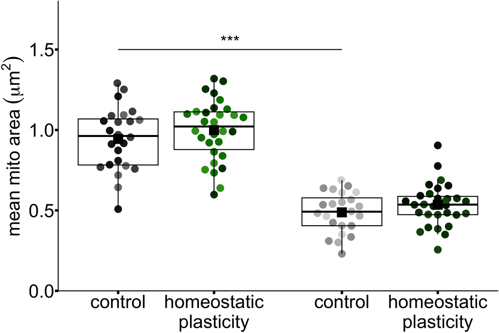

```r
set.seed(20261109)
date_levels <- levels(mito_df$Date)
group_date_colors <- c(
  setNames(rep(c("#1A1A1A", "#4D4D4D", "#777B7E"), length.out = length(date_levels)),
           paste("Juxta Control", date_levels, sep = "_")),
  setNames(rep(c("#003D00", "#008000", "#3A9D23"), length.out = length(date_levels)),
           paste("Juxta TTX", date_levels, sep = "_")),
  setNames(rep(c("#9E9E9E", "#BDBDBD", "#D9D9D9"), length.out = length(date_levels)),
           paste("Non Juxta Control", date_levels, sep = "_")),
  setNames(rep(c("#001800", "#003D00", "#18500F"), length.out = length(date_levels)),
           paste("Non Juxta TTX", date_levels, sep = "_"))
)

plot_stats <- comparison_results %>%
  filter(group1 == "Juxta Control", group2 == "Non Juxta Control") %>%
  mutate(
    group1_x = unname(spacing_map[group1]),
    group2_x = unname(spacing_map[group2]),
    y_position = 1.5,
    stars = p_to_stars(p_value)
  ) %>%
  filter(stars != "ns")

fig6d_plot <- ggplot(mito_df, aes(x_pos, mito_area_um2, color = Group_Date)) +
  ggbeeswarm::geom_beeswarm(cex = 3, priority = "random", size = 15, corral = "random") +
  geom_boxplot(aes(group = x_pos), fill = NA, width = 1, outlier.shape = NA,
               linewidth = 2, color = "black") +
  stat_summary(aes(group = x_pos), fun = mean, geom = "point",
               shape = 15, size = 20, color = "black") +
  geom_segment(data = plot_stats,
               aes(x = group1_x, xend = group2_x,
                   y = y_position, yend = y_position),
               inherit.aes = FALSE, linewidth = 2, color = "black") +
  geom_text(data = plot_stats,
            aes(x = (group1_x + group2_x) / 2,
                y = y_position + 0.05, label = stars),
            inherit.aes = FALSE, size = 25, color = "black") +
  scale_x_continuous(
    breaks = unname(spacing_map),
    labels = c("control", "homeostatic\nplasticity",
               "control", "homeostatic\nplasticity")
  ) +
  scale_color_manual(values = group_date_colors) +
  scale_y_continuous(oob = scales::oob_keep, breaks = c(0, 0.5, 1, 1.5),
                     limits = c(0, 1.8), expand = c(0, 0)) +
  labs(x = NULL, y = expression(mean~mito~area~group("(", mu*m^2, ")"))) +
  theme_classic() +
  theme(
    axis.title = element_text(size = 80, color = "black"),
    axis.text = element_text(size = 80, color = "black"),
    axis.ticks = element_line(linewidth = 5, color = "black"),
    axis.ticks.length = grid::unit(0.5, "cm"),
    axis.line = element_line(linewidth = 2, color = "black"),
    legend.position = "none"
  )

fig6d_plot
```

# Fig 6E

Mitochondrial ATP reporter L/F by region and homeostatic-plasticity treatment in Matrix-PKI-expressing neurons.

**update for 2026 pending** — The adjusted juxtaspinal treatment contrast is significant, whereas the overall treatment effect is nonsignificant.

**Source data**  
`Fig 6E.csv`

**Columns**

- `Date` — Experiment date
- `Condition` — Control or TTX
- `Dish` — Culture dish ID
- `Cell` — Cell ID
- `FOV` — Field of view ID
- `Mito` — Mitochondrial region ID
- `Slice` — Image slice ID
- `L` — Luciferase luminescence
- `F` — Reporter fluorescence
- `LbyF` — Luminescence-to-fluorescence ratio (L/F)
- `region` — Juxtaspinal or non-juxtaspinal region

## Data

All cells express Matrix-PKI.

```r
PLOT_CORRECTED <- TRUE
pH_control <- 7.05
pH_scaling <- 6.98
pKa_L <- 7.03
L_corr_factor <- (1 + 10^(pKa_L - pH_scaling)) /
  (1 + 10^(pKa_L - pH_control))
plot_y <- if (PLOT_CORRECTED) "LbyF_corrected" else "LbyF"

spacing_map <- c(
  "Juxta Control" = 1, "Juxta TTX" = 2.2,
  "Non Juxta Control" = 3.8, "Non Juxta TTX" = 5
)

LbyF_df <- read_csv("./Fig 6E.csv", show_col_types = FALSE)
required_columns <- c("Date", "Condition", "region", "Cell", "Mito", "LbyF", "L", "F")
missing_columns <- setdiff(required_columns, names(LbyF_df))
if (length(missing_columns))
  stop("Missing columns: ", paste(missing_columns, collapse = ", "))

if (!"Dish" %in% names(LbyF_df)) LbyF_df$Dish <- "1"
if (!"FOV" %in% names(LbyF_df)) LbyF_df$FOV <- 1

LbyF_df <- LbyF_df %>%
  mutate(
    Condition = trimws(as.character(Condition)),
    Region = trimws(as.character(region)),
    Region = case_when(
      grepl("^Juxta$", Region, ignore.case = TRUE) ~ "Juxta",
      grepl("^Non[ _-]*Juxta$", Region, ignore.case = TRUE) ~ "Non Juxta",
      TRUE ~ Region
    )
  ) %>%
  filter(
    grepl("Matrix-PKI|Matrix PKI|MitoPKI|Mt-PKI", Condition, ignore.case = TRUE) |
      Condition %in% c("Control", "TTX")
  ) %>%
  mutate(
    Condition = case_when(
      grepl("^Control", Condition, ignore.case = TRUE) ~ "Control",
      grepl("^TTX", Condition, ignore.case = TRUE) ~ "TTX"
    ),
    Date = factor(trimws(as.character(Date))),
    Condition = factor(Condition, levels = c("Control", "TTX")),
    Region = factor(Region, levels = c("Juxta", "Non Juxta")),
    Dish = as.character(Dish),
    Cell = as.character(Cell),
    Mito = as.character(Mito),
    FOV = as.integer(coalesce(suppressWarnings(as.numeric(FOV)), 1)),
    across(c(LbyF, L, F), as.numeric)
  ) %>%
  filter(
    !is.na(Date), !is.na(Condition), !is.na(Region),
    is.finite(LbyF), is.finite(L), is.finite(F), L > 0, F > 500
  ) %>%
  mutate(
    L_corrected = if_else(Condition == "TTX", L * L_corr_factor, L),
    LbyF_corrected = L_corrected / F,
    Group = factor(paste(Region, Condition), levels = names(spacing_map)),
    x_pos = unname(spacing_map[as.character(Group)]),
    Group_Date = paste(Group, Date, sep = "_"),
    Cell_ID = paste(Date, Group, Dish, Cell, sep = "_"),
    Mito_ID = paste(Date, Group, Dish, Cell, FOV, Mito, sep = "_")
  ) %>%
  filter(is.finite(.data[[plot_y]]))

if (!nrow(LbyF_df) || n_distinct(LbyF_df$Group) < 4 || n_distinct(LbyF_df$Date) < 2)
  stop("All four Condition x Region groups and at least two dates are required.")

LbyF_df %>%
  select(Date, Condition, Dish, Cell, FOV, Mito, Region,
         LbyF, L, F, L_corrected, LbyF_corrected) %>%
  mutate(across(where(is.numeric), ~ round(.x, 3)))
```

| Date | Condition | Dish | Cell | FOV | Mito | Region | LbyF | L | F | L_corrected | LbyF_corrected |
| --- | --- | --- | --- | --- | --- | --- | --- | --- | --- | --- | --- |
| 2026-07-01 | Control | 1 | 1 | 1 | 1 | Juxta | 0.046 | 28.385 | 611.179 | 28.385 | 0.046 |
| 2026-07-01 | Control | 1 | 1 | 1 | 2 | Juxta | 0.046 | 31.226 | 672.742 | 31.226 | 0.046 |
| 2026-07-01 | Control | 1 | 1 | 1 | 3 | Juxta | 0.057 | 29.000 | 507.543 | 29.000 | 0.057 |
| 2026-07-01 | Control | 2 | 1 | 1 | 1 | Juxta | 0.051 | 32.729 | 640.312 | 32.729 | 0.051 |
| 2026-07-01 | Control | 2 | 1 | 1 | 2 | Juxta | 0.072 | 38.970 | 542.955 | 38.970 | 0.072 |
| 2026-07-01 | Control | 2 | 1 | 1 | 3 | Juxta | 0.056 | 29.514 | 523.629 | 29.514 | 0.056 |
| 2026-07-01 | Control | 2 | 1 | 1 | 4 | Juxta | 0.070 | 44.723 | 642.660 | 44.723 | 0.070 |
| 2026-07-01 | Control | 2 | 1 | 1 | 5 | Juxta | 0.059 | 35.551 | 598.510 | 35.551 | 0.059 |
| 2026-07-01 | Control | 2 | 1 | 1 | 6 | Juxta | 0.066 | 33.636 | 506.600 | 33.636 | 0.066 |
| 2026-07-01 | Control | 2 | 1 | 1 | 7 | Juxta | 0.059 | 32.115 | 540.590 | 32.115 | 0.059 |

[output cut: 188 more lines]

## Summary

```r
summary_table <- LbyF_df %>%
  group_by(Group) %>%
  summarise(
    n_Experiment_Dates = n_distinct(Date),
    n_Cells = n_distinct(Cell_ID),
    n_FOVs = n_distinct(Date, Dish, Cell, FOV),
    n_Mitochondria = n_distinct(Mito_ID),
    `Mean (SE)` = sprintf("%.3f (%.3f)", mean(.data[[plot_y]]),
                          sd(.data[[plot_y]]) / sqrt(n())),
    .groups = "drop"
  )

summary_table
```

| Group | n_Experiment_Dates | n_Cells | n_FOVs | n_Mitochondria | Mean (SE) |
| --- | --- | --- | --- | --- | --- |
| Juxta Control | 3 | 8 | 9 | 91 | 0.085 (0.003) |
| Juxta TTX | 3 | 6 | 7 | 67 | 0.092 (0.006) |
| Non Juxta Control | 3 | 5 | 6 | 14 | 0.072 (0.007) |
| Non Juxta TTX | 3 | 5 | 5 | 26 | 0.062 (0.005) |

## Statistics

Three-way ANOVA with condition, region, experiment date, and their interactions (Type I sums of squares). Pairwise comparisons use Tukey adjustment.

```r
format_p <- function(p) ifelse(is.na(p), NA_character_,
                               ifelse(p < 0.0001, "<0.0001", sprintf("%.4f", p)))
p_to_stars <- function(p) case_when(
  is.na(p) ~ NA_character_, p < 0.001 ~ "***",
  p < 0.01 ~ "**", p < 0.05 ~ "*", TRUE ~ "ns"
)

fit_aov <- aov(
  as.formula(paste(plot_y, "~ Condition * Region * Date")),
  data = LbyF_df
)
aov_tab <- anova(fit_aov)

anova_table <- as.data.frame(aov_tab) %>%
  tibble::rownames_to_column("Effect") %>%
  filter(trimws(Effect) != "Residuals") %>%
  transmute(
    Effect = dplyr::recode(
      trimws(Effect),
      Condition = "Condition", Region = "Region", Date = "Date",
      `Condition:Region` = "Condition x Region",
      `Condition:Date` = "Condition x Date",
      `Region:Date` = "Region x Date",
      `Condition:Region:Date` = "Condition x Region x Date"
    ),
    df = Df, F = round(`F value`, 3), `p value` = format_p(`Pr(>F)`)
  )

anova_table
```

| Effect | df | F | p value |
| --- | --- | --- | --- |
| Condition | 1 | 0.026 | 0.8711 |
| Region | 1 | 18.923 | <0.0001 |
| Date | 2 | 27.310 | <0.0001 |
| Condition x Region | 1 | 0.920 | 0.3387 |
| Condition x Date | 2 | 2.752 | 0.0664 |
| Region x Date | 2 | 2.793 | 0.0638 |
| Condition x Region x Date | 2 | 2.364 | 0.0969 |

```r
cell_emm <- emmeans::emmeans(fit_aov, ~ Region * Condition)
cell_means <- as.data.frame(cell_emm) %>%
  mutate(Group = paste(Region, Condition))

pair_list <- combn(cell_means$Group, 2, simplify = FALSE)
contrast_list <- setNames(lapply(pair_list, function(pair) {
  contrast_vector <- rep(0, nrow(cell_means))
  contrast_vector[match(pair[1], cell_means$Group)] <- 1
  contrast_vector[match(pair[2], cell_means$Group)] <- -1
  contrast_vector
}), vapply(pair_list, paste, collapse = " || ", FUN.VALUE = character(1)))

all_pairs <- emmeans::contrast(cell_emm, method = contrast_list, adjust = "tukey") %>%
  as.data.frame() %>%
  transmute(pair = contrast, p_value = p.value)

comparison_results <- tibble(
  group1 = c("Juxta Control", "Non Juxta Control", "Juxta Control", "Juxta TTX"),
  group2 = c("Juxta TTX", "Non Juxta TTX", "Non Juxta Control", "Non Juxta TTX")
) %>%
  rowwise() %>%
  mutate(
    direct_pair = paste(group1, group2, sep = " || "),
    reverse_pair = paste(group2, group1, sep = " || "),
    p_value = {
      matched <- all_pairs$p_value[
        all_pairs$pair %in% c(direct_pair, reverse_pair)
      ]
      if (length(matched) != 1) stop("Tukey comparison not found: ", group1, " vs ", group2)
      matched
    }
  ) %>%
  ungroup() %>%
  select(group1, group2, p_value)

group_means <- setNames(summary_table$`Mean (SE)`, as.character(summary_table$Group))

stats_table <- comparison_results %>%
  transmute(
    Test = "Three-way ANOVA with Tukey post hoc",
    Comparison = paste(group1, "vs", group2),
    `Group 1 mean (SE)` = unname(group_means[group1]),
    `Group 2 mean (SE)` = unname(group_means[group2]),
    `Condition p` = format_p(aov_tab["Condition", "Pr(>F)"]),
    `Region p` = format_p(aov_tab["Region", "Pr(>F)"]),
    `Condition x Region p` = format_p(aov_tab["Condition:Region", "Pr(>F)"]),
    `Tukey p` = format_p(p_value)
  )

stats_table
```

| Test | Comparison | Group 1 mean (SE) | Group 2 mean (SE) | Condition p | Region p | Condition x Region p | Tukey p |
| --- | --- | --- | --- | --- | --- | --- | --- |
| Three-way ANOVA with Tukey post hoc | Juxta Control vs Juxta TTX | 0.085 (0.003) | 0.092 (0.006) | 0.8711 | <0.0001 | 0.3387 | <0.0001 |
| Three-way ANOVA with Tukey post hoc | Non Juxta Control vs Non Juxta TTX | 0.072 (0.007) | 0.062 (0.005) | 0.8711 | <0.0001 | 0.3387 | 0.9848 |
| Three-way ANOVA with Tukey post hoc | Juxta Control vs Non Juxta Control | 0.085 (0.003) | 0.072 (0.007) | 0.8711 | <0.0001 | 0.3387 | 0.9703 |
| Three-way ANOVA with Tukey post hoc | Juxta TTX vs Non Juxta TTX | 0.092 (0.006) | 0.062 (0.005) | 0.8711 | <0.0001 | 0.3387 | 0.0028 |

## Plot

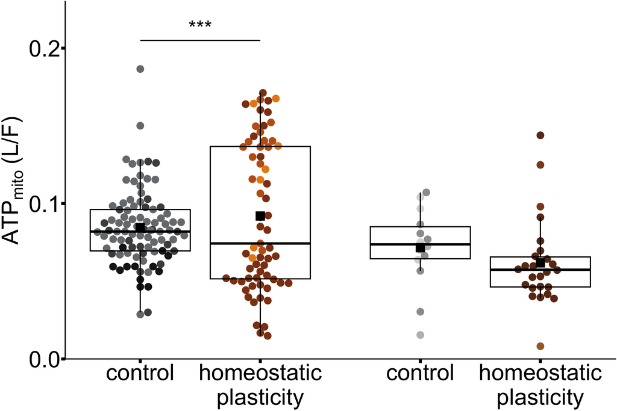

```r
set.seed(20261109)
date_levels <- levels(LbyF_df$Date)
group_date_colors <- c(
  setNames(rep(c("#1A1A1A", "#4D4D4D", "#777B7E"), length.out = length(date_levels)), paste("Juxta Control", date_levels, sep = "_")),
  setNames(rep(c("#8F3F12", "#C26018", "#E88A16"), length.out = length(date_levels)), paste("Juxta TTX", date_levels, sep = "_")),
  setNames(rep(c("#BDBDBD", "#D9D9D9", "#9E9E9E"), length.out = length(date_levels)), paste("Non Juxta Control", date_levels, sep = "_")),
  setNames(rep(c("#6B3518", "#8C4A24", "#A66A2C"), length.out = length(date_levels)), paste("Non Juxta TTX", date_levels, sep = "_"))
)

plot_stats <- comparison_results %>%
  filter(group1 == "Juxta Control", group2 == "Juxta TTX") %>%
  mutate(
    group1_x = unname(spacing_map[group1]),
    group2_x = unname(spacing_map[group2]),
    y_position = 0.205,
    stars = p_to_stars(p_value)
  ) %>%
  filter(stars != "ns")

fig6e_plot <- ggplot(LbyF_df, aes(x_pos, .data[[plot_y]], color = Group_Date)) +
  ggbeeswarm::geom_beeswarm(cex = 2, priority = "random", size = 12, corral = "random") +
  geom_boxplot(aes(group = x_pos), fill = NA, width = 1, outlier.shape = NA,
               linewidth = 2, color = "black") +
  stat_summary(aes(group = x_pos), fun = mean, geom = "point",
               shape = 15, size = 15, color = "black") +
  geom_segment(
    data = plot_stats,
    aes(x = group1_x, xend = group2_x, y = y_position, yend = y_position),
    inherit.aes = FALSE, linewidth = 2, color = "black"
  ) +
  geom_text(
    data = plot_stats,
    aes(x = (group1_x + group2_x) / 2, y = y_position + 0.008, label = stars),
    inherit.aes = FALSE, size = 25, color = "black"
  ) +
  scale_x_continuous(
    breaks = unname(spacing_map),
    labels = c("control", "homeostatic\nplasticity",
               "control", "homeostatic\nplasticity")
  ) +
  scale_color_manual(values = group_date_colors) +
  scale_y_continuous(oob = scales::oob_keep,
    breaks = c(0, 0.1, 0.2),
    limits = c(0, 0.23), expand = c(0, 0)
  ) +
  labs(x = NULL, y = expression(ATP[mito]~"(L/F)")) +
  theme_classic() +
  theme(
    axis.title = element_text(size = 80, color = "black"),
    axis.text.x = element_text(size = 80, color = "black"),
    axis.text.y = element_text(size = 80, color = "black"),
    axis.ticks = element_line(linewidth = 5, color = "black"),
    axis.ticks.length = grid::unit(0.5, "cm"),
    axis.line = element_line(linewidth = 2, color = "black"),
    legend.position = "none"
  )

fig6e_plot
```

# Fig 6F

Juxtaspinal mitochondrial area after single-spine plasticity induction in control and Matrix-PKI neurons.

**Source data**  
`Fig 6F.csv`

**Columns**

- `Date` — Experiment date
- `Condition` — Control or Matrix-PKI
- `Dish` — Culture dish ID
- `Cell` — Cell ID
- `Spine` — Spine ID
- `Time` — Time relative to induction (min)
- `mito_area_um2` — Mitochondrial area (µm²)
- `norm_mito_area_um2` — Baseline-normalized mitochondrial area (unitless)

## Data

Baseline-normalized area is averaged across the ten measurements from 17 to 62 min per complete trace.

```r
condition_order <- c("Control", "Matrix-PKI")
condition_colors <- c("Control" = "#00DC00", "Matrix-PKI" = "#008000")
X_BREAKS <- c(-2, 2, 12, 22, 32, 42, 52, 62)

Mito <- read_csv("./Fig 6F.csv", show_col_types = FALSE) %>%
  mutate(
    Condition = if_else(Condition == "Matrix PKI", "Matrix-PKI", Condition),
    Condition = factor(Condition, levels = condition_order),
    Date = trimws(as.character(Date)),
    across(c(Dish, Cell, Spine, Time, mito_area_um2, norm_mito_area_um2), as.numeric)
  ) %>%
  filter(!is.na(Condition), !is.na(Date), Date != "", is.finite(Time))

time_levels <- sort(unique(Mito$Time))
if (length(time_levels) < 16) stop("At least 16 ordered time points are required.")

Mito %>% mutate(across(where(is.numeric), ~ round(.x, 3)))
```

| Date | Condition | Dish | Cell | Spine | Time | mito_area_um2 | norm_mito_area_um2 |
| --- | --- | --- | --- | --- | --- | --- | --- |
| 2026-05-06 | Control | 1 | 2 | 1 | -2 | 1.304 | 1.040 |
| 2026-05-06 | Control | 1 | 2 | 1 | -1 | 1.204 | 0.960 |
| 2026-05-06 | Control | 1 | 2 | 1 | 0 | 1.254 | 1.000 |
| 2026-05-06 | Control | 1 | 2 | 1 | 2 | 1.184 | 0.944 |
| 2026-05-06 | Control | 1 | 2 | 1 | 7 | 1.385 | 1.104 |
| 2026-05-06 | Control | 1 | 2 | 1 | 12 | 1.395 | 1.112 |
| 2026-05-06 | Control | 1 | 2 | 1 | 17 | 1.415 | 1.128 |
| 2026-05-06 | Control | 1 | 2 | 1 | 22 | 1.244 | 0.992 |
| 2026-05-06 | Control | 1 | 2 | 1 | 27 | 1.294 | 1.032 |
| 2026-05-06 | Control | 1 | 2 | 1 | 32 | 1.314 | 1.048 |

[output cut: 854 more lines]

## Summary

```r
summary_table <- Mito %>%
  group_by(Condition) %>%
  summarise(
    n_Spines = n_distinct(paste(Condition, Date, Dish, Cell, Spine, sep = "_")),
    n_Cells = n_distinct(paste(Date, Dish, Cell, sep = "_")),
    n_Biological_Replicates = n_distinct(case_when(
      Condition == "Control" & Date %in% c("2026-05-06", "2026-05-08") ~ "2026-05-06",
      Condition == "Control" & Date %in% c("2026-06-10", "2026-06-12") ~ "2026-06-10",
      Condition == "Matrix-PKI" & Date %in% c("2026-06-10", "2026-06-11") ~ "2026-06-10",
      Condition == "Matrix-PKI" & Date %in% c("2026-06-17", "2026-06-18") ~ "2026-06-17",
      TRUE ~ Date
    )),
    .groups = "drop"
  )

summary_table
```

| Condition | n_Spines | n_Cells | n_Biological_Replicates |
| --- | --- | --- | --- |
| Control | 32 | 22 | 6 |
| Matrix-PKI | 22 | 12 | 3 |

## Statistics

One-way ANOVA if both groups pass Shapiro–Wilk (p > 0.05), otherwise Kruskal–Wallis.

```r
comparison_times <- time_levels[7:16]
format_p <- function(p) ifelse(p < 0.0001, "<0.0001", sprintf("%.4f", p))
p_to_stars <- function(p) case_when(p < 0.001 ~ "***", p < 0.01 ~ "**", p < 0.05 ~ "*", TRUE ~ "ns")

norm_compare <- Mito %>%
  mutate(time_order = match(Time, time_levels),
         TraceID = paste(Condition, Date, Dish, Cell, Spine, sep = "_")) %>%
  filter(time_order %in% 7:16, is.finite(norm_mito_area_um2)) %>%
  group_by(Condition, TraceID) %>%
  summarise(value = mean(norm_mito_area_um2), n_timepoints = n_distinct(time_order), .groups = "drop") %>%
  filter(n_timepoints == length(comparison_times))

if (n_distinct(norm_compare$Condition) < 2)
  stop("Both Control and Matrix-PKI need complete spines for this comparison.")

safe_shapiro <- function(x) {
  if (length(x) < 3 || length(x) > 5000 || sd(x) == 0) return(NA_real_)
  shapiro.test(x)$p.value
}

normality <- norm_compare %>% group_by(Condition) %>%
  summarise(Shapiro_p = safe_shapiro(value), Normal = !is.na(Shapiro_p) & Shapiro_p > 0.05, .groups = "drop")

normality
```

| Condition | Shapiro_p | Normal |
| --- | --- | --- |
| Control | 1.947091e-05 | FALSE |
| Matrix-PKI | 2.369444e-02 | FALSE |

```r
if (all(normality$Normal)) {
  norm_fit <- aov(value ~ Condition, data = norm_compare)
  norm_test <- "One-way ANOVA"
  norm_p <- as.numeric(anova(norm_fit)["Condition", "Pr(>F)"])
} else {
  norm_fit <- kruskal.test(value ~ Condition, data = norm_compare)
  norm_test <- "Kruskal-Wallis"
  norm_p <- norm_fit$p.value
}

norm_means <- norm_compare %>% group_by(Condition) %>%
  summarise(`Mean (SE)` = sprintf("%.3f (%.3f)", mean(value), sd(value) / sqrt(n())), .groups = "drop")
mean_lookup <- setNames(norm_means$`Mean (SE)`, as.character(norm_means$Condition))

stats_table <- tibble(
  Test = norm_test,
  Statistic = if (inherits(norm_fit,"htest")) unname(norm_fit$statistic) else anova(norm_fit)$`F value`[1],
  df1 = if (inherits(norm_fit,"htest")) unname(norm_fit$parameter) else anova(norm_fit)$Df[1],
  df2 = if (inherits(norm_fit,"htest")) NA_real_ else anova(norm_fit)$Df[2],
  Comparison = "Control vs Matrix-PKI",
  `Time range` = paste0(min(comparison_times), "-", max(comparison_times)),
  `Control mean (SE)` = unname(mean_lookup["Control"]),
  `Matrix-PKI mean (SE)` = unname(mean_lookup["Matrix-PKI"]),
  `p value` = format_p(norm_p)
)

stats_table
```

| Test | Statistic | df1 | df2 | Comparison | Time range | Control mean (SE) | Matrix-PKI mean (SE) | p value |
| --- | --- | --- | --- | --- | --- | --- | --- | --- |
| Kruskal-Wallis | 4.68874 | 1 | NA | Control vs Matrix-PKI | 17-62 | 1.110 (0.033) | 1.026 (0.023) | 0.0304 |

## Plot

The red bar marks single-spine induction from 0 to 2 min.

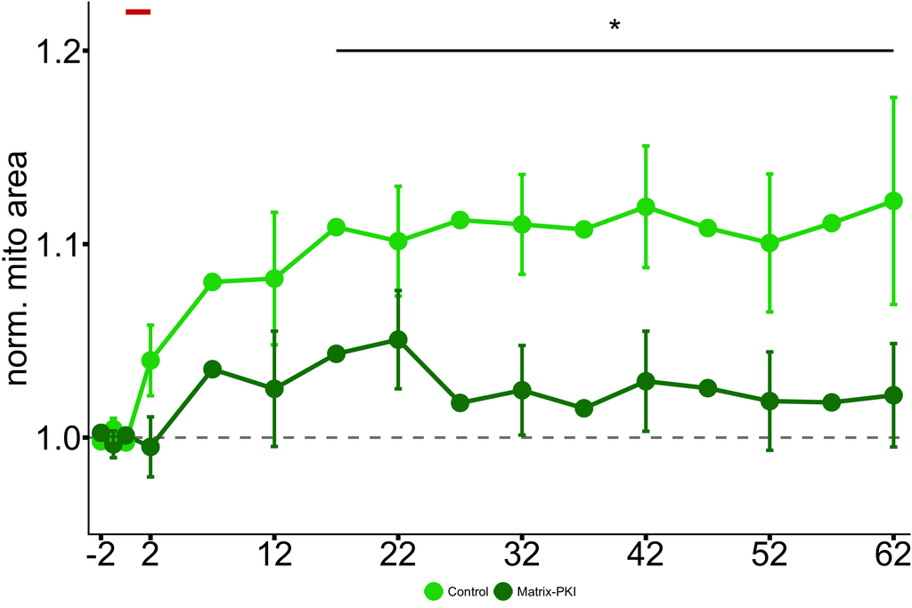

```r
set.seed(20261109)
norm_summary <- Mito %>%
  mutate(time_order = match(Time, time_levels)) %>%
  filter(is.finite(norm_mito_area_um2)) %>%
  group_by(Condition, Time, time_order) %>%
  summarise(mean_value = mean(norm_mito_area_um2),
            sem = sd(norm_mito_area_um2) / sqrt(n()), .groups = "drop")

errorbars <- norm_summary %>% filter(time_order %% 2 == 0, is.finite(sem))
plot_stats <- tibble(
  x_start = min(comparison_times), x_end = max(comparison_times),
  x_label = (x_start + x_end) / 2, stars = p_to_stars(norm_p)
) %>% filter(stars != "ns")

norm_plot <- ggplot(norm_summary, aes(Time, mean_value, color = Condition, group = Condition)) +
  geom_hline(yintercept = 1, color = "grey50", linetype = "dashed", linewidth = 3) +
  geom_line(linewidth = 5) +
  geom_point(size = 20) +
  geom_errorbar(data = errorbars, aes(ymin = mean_value - sem, ymax = mean_value + sem),
                width = 0.6, linewidth = 4) +
  geom_segment(data = plot_stats, aes(x = x_start, xend = x_end, y = 1.2, yend = 1.2),
               inherit.aes = FALSE, color = "black", linewidth = 3) +
  geom_text(data = plot_stats, aes(x = x_label, y = 1.21, label = stars),
            inherit.aes = FALSE, color = "black", size = 28) +
  scale_color_manual(values = condition_colors, breaks = condition_order) +
  scale_x_continuous(breaks = X_BREAKS, expand = expansion(add = c(1, 1))) +
  scale_y_continuous(oob = scales::oob_keep, limits = c(0.95, 1.225), breaks = c(1.0, 1.1, 1.2), expand = c(0, 0)) +
  labs(x = NULL, y = "norm. mito area") +
  annotate("segment",x=0,xend=2,y=1.22,yend=1.22,color="#D00000",linewidth=6) +
  theme_classic() +
  theme(axis.title = element_text(size = 80, color = "black"),
        axis.text = element_text(size = 80, color = "black"),
        axis.ticks = element_line(linewidth = 5, color = "black"),
        axis.ticks.length = grid::unit(0.5, "cm"),
        axis.line = element_line(linewidth = 2, color = "black"),
        legend.position = "bottom", legend.text = element_text(size=30), legend.title = element_blank())

norm_plot
```

# Fig 6G

pH-corrected juxtaspinal mitochondrial ATP following single-spine plasticity induction in control and Matrix-PKI neurons.

**update for 2026 pending** — Matrix-PKI has four experiment dates. The v3 legend reports three biological replicates.

**Source data**  
`Fig 6G.csv`, `Fig 6G pH.csv`

**Columns**

- `Date` — Experiment date
- `Condition` — Control or Matrix-PKI
- `Dish` — Culture dish ID
- `Cell` — Cell ID
- `Mito` — Mitochondrial region ID
- `Timepoint` — Sampling index
- `Time` — Time relative to induction (min)
- `LbyF` — Luminescence-to-fluorescence ratio (L/F)
- `Control` — Mean mitochondrial pH in control neurons
- `Control_SE` — SE of the corresponding mean pH
- `PKI` — Mean mitochondrial pH in Matrix-PKI neurons
- `PKI_SE` — SE of the corresponding mean pH

## Data

Each trace is corrected with the corresponding group mean pH trace (pKa 7.03) and normalized to its first nine valid observations.

```r
input_csv <- "./Fig 6G.csv"
ph_csv <- "./Fig 6G pH.csv"
condition_order <- c("Control", "PKI")
condition_colors <- c("Control" = "#FC6A03", "PKI" = "#6B3518")
X_BREAKS <- c(-2, 0, 2, 4, 6, 8, 10, 12)
N_BASELINE_POINTS <- 9; PKA_L <- 7.03

Mito <- read_csv(input_csv, show_col_types = FALSE) %>%
  mutate(
    Date = trimws(as.character(Date)),
    Condition = trimws(as.character(Condition)),
    across(c(Dish, Cell, Mito, Timepoint, Time, LbyF), as.numeric),
    TraceID = paste(Date, Condition, Dish, Cell, Mito, sep = "_")
  ) %>%
  filter(Condition %in% condition_order, !is.na(Date), Date != "",
         is.finite(Timepoint), is.finite(Time), is.finite(LbyF)) %>%
  mutate(Condition = factor(Condition, levels = condition_order))

pH <- read_csv(ph_csv, show_col_types = FALSE)
missing_columns <- setdiff(c("Control", "PKI"), names(pH))
if (length(missing_columns)) stop("Missing pH columns: ", paste(missing_columns, collapse = ", "))
if (nrow(pH) < max(Mito$Timepoint)) stop("The pH file has fewer rows than the ATP data have time points.")

pH <- pH %>%
  transmute(Timepoint = row_number(), Control_pH = as.numeric(Control),
            PKI_pH = as.numeric(PKI))
if (any(!is.finite(pH$Control_pH[seq_len(max(Mito$Timepoint))])) ||
    any(!is.finite(pH$PKI_pH[seq_len(max(Mito$Timepoint))])))
  stop("The pH file contains missing or nonnumeric values within the ATP time range.")

control_baseline_pH <- mean(pH$Control_pH[seq_len(N_BASELINE_POINTS)])
pki_baseline_pH <- mean(pH$PKI_pH[seq_len(N_BASELINE_POINTS)])
pH <- pH %>%
  mutate(
    Control_factor = (1 + 10^(PKA_L - Control_pH)) /
      (1 + 10^(PKA_L - control_baseline_pH)),
    PKI_factor = (1 + 10^(PKA_L - PKI_pH)) /
      (1 + 10^(PKA_L - pki_baseline_pH))
  )

Mito <- Mito %>%
  left_join(pH, by = "Timepoint") %>%
  mutate(
    pH_value = if_else(Condition == "Control", Control_pH, PKI_pH),
    pH_factor = if_else(Condition == "Control", Control_factor, PKI_factor),
    raw_value = LbyF * pH_factor
  )

if (any(!is.finite(Mito$raw_value))) stop("The pH correction produced nonfinite L/F values.")

baseline_table <- Mito %>%
  filter(Timepoint <= N_BASELINE_POINTS) %>%
  group_by(Condition, TraceID) %>%
  summarise(Baseline = mean(raw_value), n_baseline = n_distinct(Timepoint), .groups = "drop") %>%
  filter(n_baseline == N_BASELINE_POINTS, is.finite(Baseline), Baseline != 0) %>%
  select(-n_baseline)

Mito <- Mito %>%
  inner_join(baseline_table, by = c("Condition", "TraceID")) %>%
  mutate(norm_LbyF = raw_value / Baseline)

if (nrow(Mito) == 0) stop("No traces have nine valid baseline points.")

Mito %>%
  select(Date, Condition, Dish, Cell, Mito, Timepoint, Time, LbyF,
         pH_value, pH_factor, raw_value, norm_LbyF) %>%
  mutate(across(where(is.numeric), ~ round(.x, 3)))
```

| Date | Condition | Dish | Cell | Mito | Timepoint | Time | LbyF | pH_value | pH_factor | raw_value | norm_LbyF |
| --- | --- | --- | --- | --- | --- | --- | --- | --- | --- | --- | --- |
| 2026-09-03 | Control | 1 | 1 | 1 | 1 | -2.667 | 0.900 | 7.189 | 1.092 | 0.982 | 0.982 |
| 2026-09-03 | Control | 1 | 1 | 1 | 2 | -2.333 | 0.955 | 7.314 | 0.980 | 0.936 | 0.935 |
| 2026-09-03 | Control | 1 | 1 | 1 | 3 | -2.000 | 0.994 | 7.292 | 0.997 | 0.991 | 0.991 |
| 2026-09-03 | Control | 1 | 1 | 1 | 4 | -1.667 | 0.959 | 7.280 | 1.007 | 0.966 | 0.965 |
| 2026-09-03 | Control | 1 | 1 | 1 | 5 | -1.333 | 1.239 | 7.289 | 1.000 | 1.238 | 1.238 |
| 2026-09-03 | Control | 1 | 1 | 1 | 6 | -1.000 | 0.903 | 7.287 | 1.001 | 0.904 | 0.904 |
| 2026-09-03 | Control | 1 | 1 | 1 | 7 | -0.667 | 1.047 | 7.342 | 0.959 | 1.005 | 1.004 |
| 2026-09-03 | Control | 1 | 1 | 1 | 8 | -0.333 | 0.954 | 7.321 | 0.974 | 0.930 | 0.929 |
| 2026-09-03 | Control | 1 | 1 | 1 | 9 | 0.000 | 1.049 | 7.284 | 1.004 | 1.053 | 1.052 |
| 2026-09-03 | Control | 1 | 1 | 1 | 10 | 2.000 | 0.914 | 7.006 | 1.326 | 1.212 | 1.211 |

[output cut: 870 more lines]

## Summary

```r
summary_table <- Mito %>%
  group_by(Condition) %>%
  summarise(
    n_Mitochondria = n_distinct(TraceID),
    n_Cells = n_distinct(Date, Dish, Cell),
    n_Experiment_Dates = n_distinct(Date),
    .groups = "drop"
  )

summary_table
```

| Condition | n_Mitochondria | n_Cells | n_Experiment_Dates |
| --- | --- | --- | --- |
| Control | 13 | 8 | 3 |
| PKI | 9 | 7 | 4 |

## Statistics

Separate one-way ANOVAs with Tukey comparisons at 2 min and on trace means over 6–12 min.

```r
window_data <- bind_rows(
  Mito %>% filter(abs(Time - 2) < 1e-4) %>% mutate(Window="2 min"),
  Mito %>% filter(Time >= 6 - 1e-4, Time <= 12 + 1e-4) %>% mutate(Window="6-12 min")
) %>% group_by(Condition, TraceID, Window) %>%
  summarise(value=mean(norm_LbyF), n_timepoints=n_distinct(Timepoint), .groups="drop")
expected_late <- n_distinct(Mito$Timepoint[Mito$Time >= 6 - 1e-4 & Mito$Time <= 12 + 1e-4])
window_data <- window_data %>% filter((Window=="2 min" & n_timepoints==1) |
                                       (Window=="6-12 min" & n_timepoints==expected_late))
window_summary <- window_data %>% group_by(Window,Condition) %>%
  summarise(n_Traces=n(),Mean=mean(value),SE=sd(value)/sqrt(n()),.groups="drop")
window_summary
```

| Window | Condition | n_Traces | Mean | SE |
| --- | --- | --- | --- | --- |
| 2 min | Control | 13 | 1.5668753 | 0.09775741 |
| 2 min | PKI | 9 | 1.0587220 | 0.08998839 |
| 6-12 min | Control | 13 | 1.3197467 | 0.14741912 |
| 6-12 min | PKI | 9 | 0.8190399 | 0.05682673 |

```r
stats_table <- bind_rows(lapply(c("2 min","6-12 min"),function(w) {
  d <- filter(window_data,Window==w)
  if (any(table(d$Condition)<2)) stop("At least two complete traces per condition are required.")
  fit <- aov(value ~ Condition,data=d)
  contrast <- as.data.frame(emmeans::contrast(emmeans::emmeans(fit,~Condition),
                                             "pairwise",adjust="tukey"))
  tab <- anova(fit)
  tibble(Window=w,Test="One-way ANOVA; Tukey comparison",Comparison="Control vs Matrix-PKI",
         df1=tab$Df[1],df2=tab$Df[2],F=tab$`F value`[1],
         Difference=contrast$estimate,SE_difference=contrast$SE,
         ANOVA_p=tab$`Pr(>F)`[1],Tukey_p=contrast$p.value)
}))
stats_table
```

| Window | Test | Comparison | df1 | df2 | F | Difference | SE_difference | ANOVA_p | Tukey_p |
| --- | --- | --- | --- | --- | --- | --- | --- | --- | --- |
| 2 min | One-way ANOVA; Tukey comparison | Control vs Matrix-PKI | 1 | 20 | 13.243481 | 0.5081533 | 0.1396348 | 0.001632772 | 0.001632772 |
| 6-12 min | One-way ANOVA; Tukey comparison | Control vs Matrix-PKI | 1 | 20 | 7.360721 | 0.5007068 | 0.1845539 | 0.013389380 | 0.013389380 |

## Plot

The red bar marks single-spine induction from 0 to 2 min.

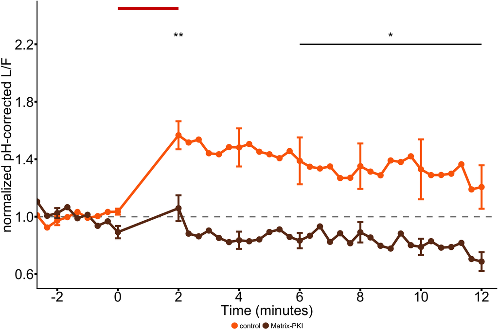

```r
set.seed(20261109)
norm_summary <- Mito %>%
  group_by(Condition, Timepoint, Time) %>%
  summarise(
    mean_value = mean(norm_LbyF),
    sem = if (n() < 2) NA_real_ else sd(norm_LbyF) / sqrt(n()),
    .groups = "drop"
  )

errorbars <- norm_summary %>%
  filter(Timepoint %in% c(3, 9, 10) |
           round(Time, 6) %in% c(4, 6, 8, 10, 12)) %>%
  filter(is.finite(sem))

plot_comparisons <- stats_table %>% mutate(
  stars=case_when(Tukey_p < 0.001 ~ "***",Tukey_p < 0.01 ~ "**",Tukey_p < 0.05 ~ "*",TRUE ~ "ns"))
point_stars <- filter(plot_comparisons,Window=="2 min",Tukey_p < 0.05)
late_stars <- filter(plot_comparisons,Window=="6-12 min",Tukey_p < 0.05)
x_limits <- c(min(Mito$Time), max(Mito$Time) + 0.5)

norm_plot <- ggplot(norm_summary, aes(Time, mean_value, color = Condition, group = Condition)) +
  geom_hline(yintercept = 1, color = "grey50", linetype = "dashed", linewidth = 3) +
  geom_line(linewidth = 5) +
  geom_point(size = 12) +
  geom_errorbar(data = errorbars, aes(ymin = mean_value - sem, ymax = mean_value + sem),
                width = 0.2, linewidth = 4) +
  geom_text(data=point_stars,aes(x=2,y=2.25,label=stars),inherit.aes=FALSE,color="black",size=20) +
  geom_segment(data=late_stars,aes(x=6,xend=12,y=2.2,yend=2.2),inherit.aes=FALSE,color="black",linewidth=3) +
  geom_text(data=late_stars,aes(x=9,y=2.25,label=stars),inherit.aes=FALSE,color="black",size=20) +
  scale_color_manual(values = condition_colors, breaks = condition_order, labels = c("control", "Matrix-PKI")) +
  scale_x_continuous(oob = scales::oob_keep, breaks = X_BREAKS, limits = x_limits, expand = c(0, 0)) +
  scale_y_continuous(oob = scales::oob_keep, limits = c(0.5, 2.5), breaks = c(0.6,1, 1.4, 1.8, 2.2), expand = c(0, 0)) +
  labs(x = "Time (minutes)", y = "normalized pH-corrected L/F") +
  annotate("segment",x=0,xend=2,y=2.45,yend=2.45,color="#D00000",linewidth=6) +
  theme_classic() +
  theme(axis.title = element_text(size = 60, color = "black"),
        axis.text = element_text(size = 60, color = "black"),
        axis.ticks = element_line(linewidth = 4, color = "black"),
        axis.ticks.length = grid::unit(0.4, "cm"),
        axis.line = element_line(linewidth = 2, color = "black"),
        legend.position = "bottom", legend.text = element_text(size=30), legend.title = element_blank())

norm_plot
```

# Fig 6H

Normalized spine size after single-spine plasticity induction in control and Matrix-PKI neurons.

**update for 2026 pending** — Biological replicate IDs are unavailable for the spine traces.

**Source data**  
`Fig 6H.csv`

**Columns**

- `Condition` — Control or Matrix-PKI
- `Spine` — Spine ID
- `time_min` — Time relative to induction (min)
- `normalized_fwhm` — Baseline-normalized spine full width at half maximum

## Data

The long-format CSV contains the measured values from the Control and Matrix-PKI workbook sheets.

```r
input_file <- "./Fig 6H.csv"
condition_order <- c("Control", "Matrix-PKI")
condition_colors <- c("Control"="#C8C8C8", "Matrix-PKI"="#1A1A1A")
anova_times <- c(17,22,27,32,37,42,47,52,57,62)
X_BREAKS <- c(0,2,12,22,32,42,52,62)
FWHM <- read_csv(input_file,show_col_types=FALSE) %>%
  mutate(Condition=factor(Condition,levels=condition_order),
         Spine=as.character(Spine),SpineID=paste(Condition,Spine,sep="_"),
         time_min=as.numeric(time_min),normalized_fwhm=as.numeric(normalized_fwhm)) %>%
  filter(!is.na(Condition),is.finite(time_min),is.finite(normalized_fwhm))
if (!nrow(FWHM)) stop("No valid spine-size measurements were loaded.")

FWHM %>% mutate(across(where(is.numeric), ~ round(.x, 3)))
```

| Condition | Spine | time_min | normalized_fwhm | SpineID |
| --- | --- | --- | --- | --- |
| Control | spine1 | -2 | 0.999 | Control_spine1 |
| Control | spine2 | -2 | 1.027 | Control_spine2 |
| Control | spine3 | -2 | 1.100 | Control_spine3 |
| Control | spine4 | -2 | 0.905 | Control_spine4 |
| Control | spine5 | -2 | 0.832 | Control_spine5 |
| Control | spine6 | -2 | 0.953 | Control_spine6 |
| Control | spine7 | -2 | 1.059 | Control_spine7 |
| Control | spine8 | -2 | 1.023 | Control_spine8 |
| Control | spine9 | -2 | 1.165 | Control_spine9 |
| Control | spine10 | -2 | 1.078 | Control_spine10 |

[output cut: 821 more lines]

## Summary

```r
summary_table <- FWHM %>%
  group_by(Condition) %>%
  summarise(n_Spines = n_distinct(SpineID), n_Timepoints = n_distinct(time_min),
            n_Observations = n(), .groups = "drop")

summary_table
```

| Condition | n_Spines | n_Timepoints | n_Observations |
| --- | --- | --- | --- |
| Control | 32 | 16 | 498 |
| Matrix-PKI | 22 | 16 | 333 |

## Statistics

Mixed repeated-measures ANOVA on complete traces from 17 to 62 min (Type III sums of squares). Condition is between spines and time is within spine.

```r
anova_source <- FWHM %>% filter(time_min %in% anova_times)
time_check <- anova_source %>% group_by(Condition) %>%
  summarise(n_Times = n_distinct(time_min), .groups = "drop")
if (nrow(time_check) != 2 || any(time_check$n_Times != length(anova_times)))
  stop("Both conditions must contain every selected ANOVA time point.")

duplicate_rows <- anova_source %>% count(Condition, SpineID, time_min) %>% filter(n > 1)
if (nrow(duplicate_rows)) stop("Duplicate spine measurements were found at an ANOVA time point.")

complete_spines <- anova_source %>%
  distinct(Condition, SpineID, time_min) %>%
  count(Condition, SpineID, name = "n_Timepoints") %>%
  filter(n_Timepoints == length(anova_times))

anova_data <- anova_source %>%
  semi_join(complete_spines, by = c("Condition", "SpineID")) %>%
  mutate(Time = factor(time_min, levels = anova_times),
         SpineID = factor(SpineID), Condition = factor(Condition, levels = condition_order))

spine_check <- anova_data %>% group_by(Condition) %>%
  summarise(n_Spines = n_distinct(SpineID), .groups = "drop")
if (nrow(spine_check) != 2 || any(spine_check$n_Spines < 2))
  stop("Each condition needs at least two complete spines.")

options(contrasts = c("contr.sum", "contr.poly"))
mixed_fit <- suppressMessages(afex::aov_ez(
  id = "SpineID", dv = "normalized_fwhm", between = "Condition", within = "Time",
  data = anova_data, type = 3, anova_table = list(correction = "none", es = "ges")
))

format_p <- function(p) ifelse(p < 0.0001, "<0.0001", sprintf("%.4f", p))
p_to_stars <- function(p) case_when(p < 0.001 ~ "***", p < 0.01 ~ "**", p < 0.05 ~ "*", TRUE ~ "ns")
anova_results <- as.data.frame(mixed_fit$anova_table) %>% tibble::rownames_to_column("Effect")
condition_p <- as.numeric(anova_results$`Pr(>F)`[anova_results$Effect == "Condition"])
if (length(condition_p) != 1) stop("Condition p-value was not found.")

spine_check
```

| Condition | n_Spines |
| --- | --- |
| Control | 29 |
| Matrix-PKI | 19 |

```r
stats_table <- anova_results %>%
  transmute(Test = "Two-way mixed repeated-measures ANOVA", Effect,
            F = round(as.numeric(F), 3), df1 = as.numeric(`num Df`),
            df2 = as.numeric(`den Df`), `p value` = format_p(`Pr(>F)`))

stats_table
```

| Test | Effect | F | df1 | df2 | p value |
| --- | --- | --- | --- | --- | --- |
| Two-way mixed repeated-measures ANOVA | Condition | 5.509 | 1 | 46 | 0.0233 |
| Two-way mixed repeated-measures ANOVA | Time | 1.516 | 9 | 414 | 0.1398 |
| Two-way mixed repeated-measures ANOVA | Condition:Time | 1.484 | 9 | 414 | 0.1515 |

## Plot

The red bar marks single-spine induction from 0 to 2 min.

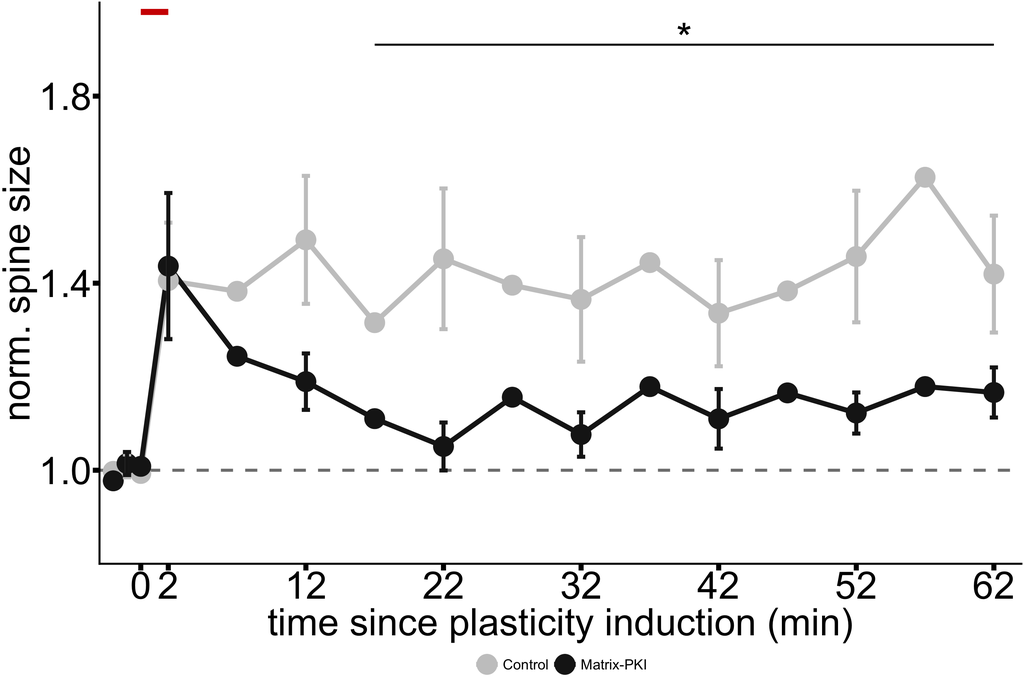

```r
set.seed(20261109)
plot_summary <- FWHM %>%
  group_by(Condition, time_min) %>%
  summarise(mean_value = mean(normalized_fwhm),
            sem = sd(normalized_fwhm) / sqrt(n()), .groups = "drop") %>%
  arrange(Condition, time_min) %>%
  group_by(Condition) %>% mutate(time_order = row_number()) %>% ungroup()

errorbars <- plot_summary %>% filter(time_order %% 2 == 0, is.finite(sem))
plot_stats <- tibble(
  x_start = min(anova_times), x_end = max(anova_times),
  x_center = mean(anova_times), stars = p_to_stars(condition_p)
) %>% filter(stars != "ns")

fig6h_plot <- ggplot(plot_summary, aes(time_min, mean_value, color = Condition, group = Condition)) +
  geom_hline(yintercept = 1, color = "grey50", linetype = "dashed", linewidth = 3) +
  geom_line(linewidth = 5) +
  geom_point(size = 20) +
  geom_errorbar(data = errorbars, aes(ymin = mean_value - sem, ymax = mean_value + sem),
                width = 0.6, linewidth = 4) +
  geom_segment(data = plot_stats, aes(x = x_start, xend = x_end, y = 1.91, yend = 1.91),
               inherit.aes = FALSE, color = "black", linewidth = 2) +
  geom_text(data = plot_stats, aes(x = x_center, y = 1.925, label = stars),
            inherit.aes = FALSE, color = "black", size = 30) +
  scale_color_manual(values = condition_colors, breaks = condition_order) +
  scale_x_continuous(oob = scales::oob_keep, breaks = X_BREAKS, limits = c(-3, 64), expand = c(0, 0)) +
  scale_y_continuous(oob = scales::oob_keep, breaks = c(1.0, 1.4, 1.8), limits = c(0.8, 2.0), expand = c(0, 0)) +
  labs(x = "time since plasticity induction (min)", y = "norm. spine size") +
  annotate("segment",x=0,xend=2,y=1.98,yend=1.98,color="#D00000",linewidth=6) +
  theme_classic() +
  theme(axis.title = element_text(size = 80, color = "black"),
        axis.text = element_text(size = 80, color = "black"),
        axis.ticks = element_line(linewidth = 5, color = "black"),
        axis.ticks.length = grid::unit(0.5, "cm"),
        axis.line = element_line(linewidth = 2, color = "black"),
        legend.position = "bottom", legend.text = element_text(size=30), legend.title = element_blank())

fig6h_plot
```